# Projet Stats-App

```r
library(readr)
library(tidyverse)
library(dplyr)
library(questionr)
```

```r
library(corrplot)
library(Hmisc)
library(lmtest)
library(margins)
library(psych)
library(rmarkdown)
library(markdown)
library(ggplot2)
library(lubridate)
library(car)
```

# Statistiques descriptives

Nous produirons des statistiques descriptives bivariées, en observant la fréquence de chacune des modalités des variables dans la base des logements du parc privé (data_p), et en sélectionnant uniquement les logements vacants.

- 1. Principales statistiques du parc privé
- 2. Statistiques sur les caractéristiques des logements
  - 2.1. Type de logement (maison ou appartement)
  - 2.2. Logement en mono ou copropriété
  - 2.3. Date de construction du logement
  - 2.4. Niveau du confort du logement
  - 2.5. Nombre de baignoires
  - 2.6. Nombre de douches
  - 2.7. Nombre de WC
  - 2.8. Surface habitable du logement
  - 2.9 Dépendance du logement
  - 2.10. Nombre de pièces
- 3. Statistiques sur les caractéristiques propres aux logements vacants
  - 3.1. Taxes TLV (en zones tendues)
  - 3.2. Taxes THLV (en zones non tendues)
  - 3.3. Valeur actualisée du logement, revalorisée à l’année 2019
  - 3.4. Début de la vacance
- 4. Statistiques sur les caractéristiques des propriétaires
  - 4.1. Type de propriétaire
  - 4.2. Année de naissance du propriétaire
  - 4.3. Nombre de droits des propriétaires
  - 4.4. Nombre de logements détenus par les propriétaires
  - 4.5. Proximité du propriétaire avec le logement

```r
data_p <- read.csv("data_finale_9_2.csv",sep=',')
```

## 1.Principales statistiques du parc privé

```r
print(sum(data_p$vacancy == 1)/nrow(data_p)*100)
```

```
## [1] 10.00026
```

```r
print(sum(data_p$ld_vacancy == 1)/nrow(data_p)*100)
```

```
## [1] 4.071994
```

```r
print(sum(data_p$ld_vacancy == 1)/sum(data_p$vacancy ==1)*100)
```

```
## [1] 40.71889
```

```r
print(sum(data_p$comparaison == "Propriété occupante")/nrow(data_p)*100)
```

```
## [1] 49.84893
```

```r
print(sum(data_p$comparaison == "Residences secondaires")/nrow(data_p)*100)
```

```
## [1] 15.94569
```

```r
print(sum(data_p$comparaison == "Parc privé locatif")/nrow(data_p)*100)
```

```
## [1] 24.20512
```

En se focalisant uniquement sur les logements vacants en Isère (38), on observe que :

Globalement, on peut donc dire que l’Isère est en moyenne moins touchée par le phénomène de vacance que la région Rhônes-Alpes dans son ensemble.

Création du dataframe contenant les statistiques principales

```r
LV <- table(data_p$dep_nom[data_p$vacancy==1])
LVLD <- table(data_p$dep_nom[data_p$ld_vacancy==1])
PP <- table(data_p$dep_nom)

LV_PP <- round(LV/PP,3)
LVLD_LV <- round(LVLD/LV,3)
LVLD_PP <- round(LVLD/PP,3)

df_stat_dep <- as.data.frame(cbind(PP,LV,LV_PP,LVLD_LV,LVLD_PP))
df_stat_dep
```

```
##                  PP    LV LV_PP LVLD_LV LVLD_PP
## Ain          268976 26124 0.097   0.451   0.044
## Allier       189626 27773 0.146   0.569   0.083
## Ardèche      193741 23107 0.119   0.525   0.063
## Cantal        92972 11502 0.124   0.607   0.075
## Drôme        246178 25057 0.102   0.376   0.038
## Haute-Loire  137163 18877 0.138   0.606   0.083
## Haute-Savoie 456863 32015 0.070   0.310   0.022
## Isère        554870 47293 0.085   0.318   0.027
## Loire        344887 44988 0.130   0.423   0.055
## Puy-de-Dôme  341592 40551 0.119   0.534   0.063
## Rhône        746927 66463 0.089   0.208   0.019
## Savoie       283455 21985 0.078   0.456   0.035
```

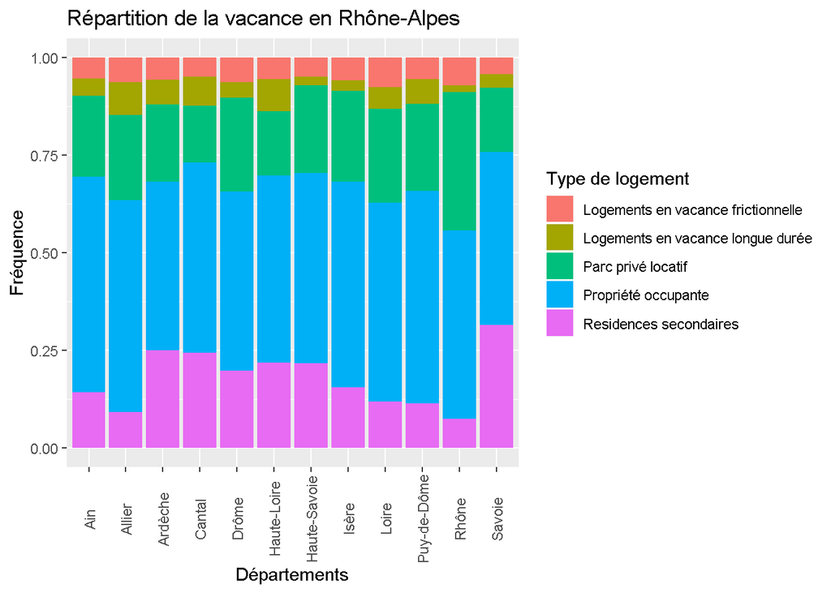

```r
ggplot(data_p,aes(as.factor(dep_nom)))+
  geom_bar(aes(fill=as.factor(comparaison)),position = "fill")+
  labs(x="Départements", y="Fréquence")+
  ggtitle("Répartition de la vacance en Rhône-Alpes")+
  theme(axis.text.x = element_text(angle = 90, vjust=0.5))+
  scale_fill_discrete(name="Type de logement")
```

L’histogramme **Répartition de la vacance en Rhône-Alpes** présente les proportions de type de logements du parc privé, calculées dans le tableau précédent. Les logements vacants (*rouge+vert* sur l’histogramme) représentent entre 7 % et 14 % du parc privé. La proportion de logements vacants est minimale (7 %) dans les département de Savoie et Haute-Savoie, alors qu’elle est maximale (14 %) dans l’Allier.

De plus, parmi tous les logements vacants, entre 21 % et 61 % des logements sont vacants depuis plus de 2 ans. La proportion est minimale (21 %) dans le département du Rhône et maximale (61 %) dans le Cantal et la Haute-Loire.

## 2. Statistiques sur les caractéristiques des logements

### 2.1. Type de logement (maison ou appartement)

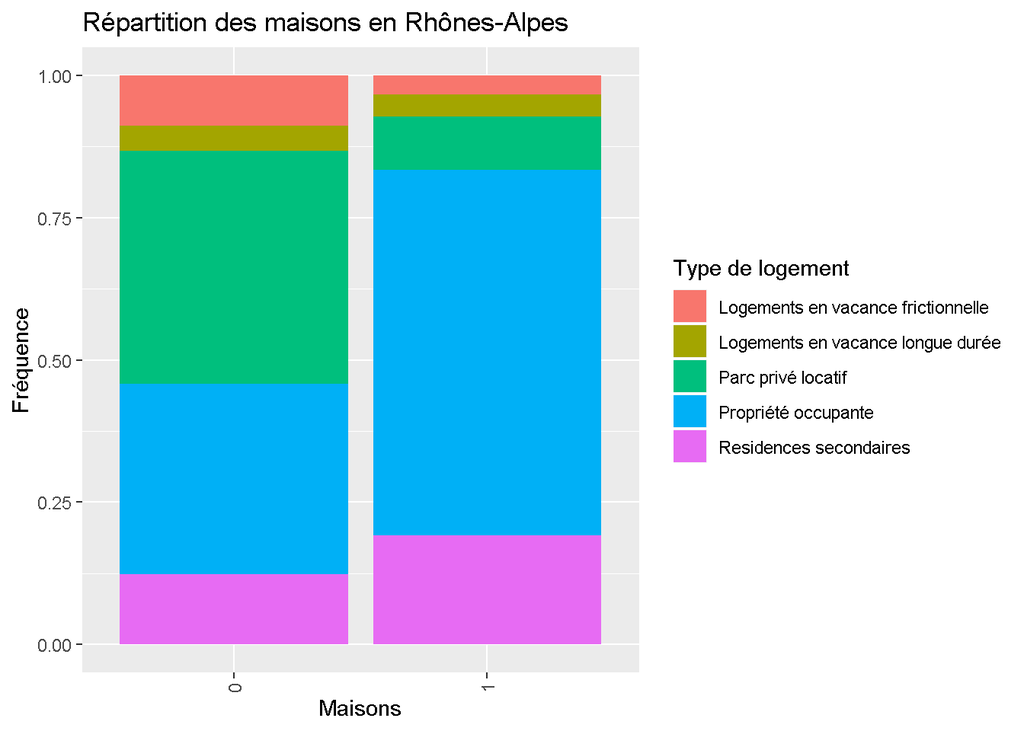

```r
ggplot(data_p,aes(as.factor(maison)))+
  geom_bar(aes(fill=as.factor(comparaison)),position = "fill")+
  labs(x="Maisons", y="Fréquence")+
  ggtitle("Répartition des maisons en Rhônes-Alpes")+
  theme(axis.text.x = element_text(angle = 90, vjust=0.5))+
  scale_fill_discrete(name="Type de logement")
```

On constate que dans la base du parc privé comme dans l’ensemble des logements vacants de longue durée, la moitié des biens sont des appartements, et l’autre moitié sont des maisons. On trouve néanmoins moins de maisons que d’appartements dans le parc de logements en vacance frictionnelle.

Ce graphe permet également de remarquer que les maisons sont davantage des résidences secondaires ou des logements occupés par leurs propriétaires, alors que les appartements appartiennent plus fréquemment au parc privé locatif.

### 2.2. Logement en mono ou copropriété

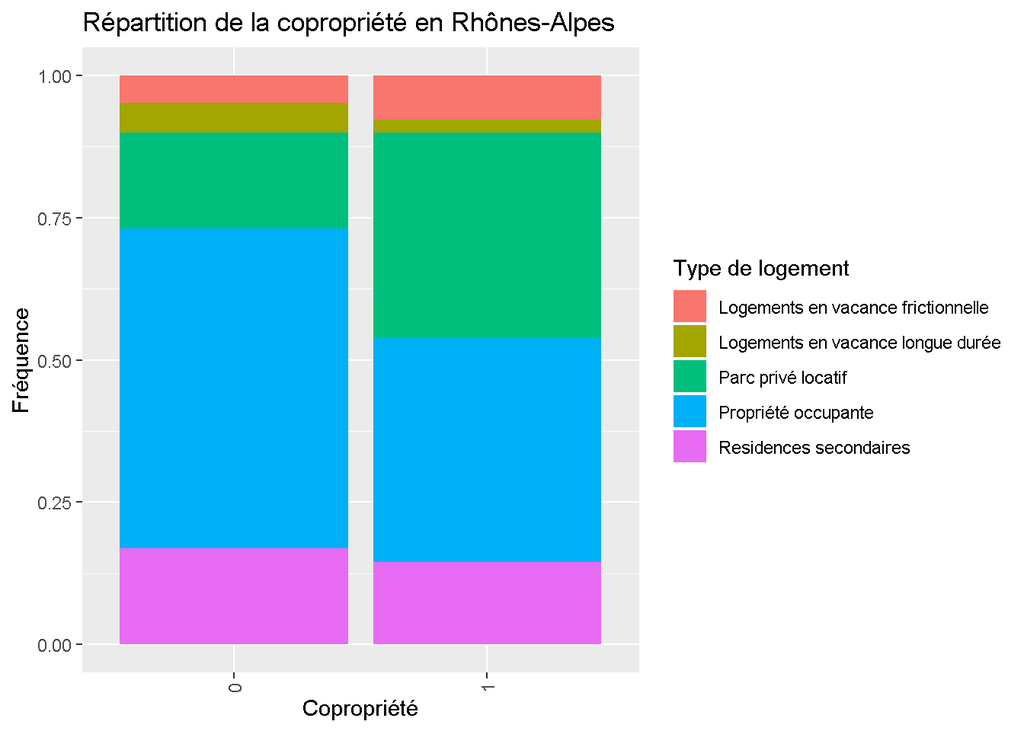

```r
ggplot(data_p,aes(as.factor(coprop)))+
  geom_bar(aes(fill=as.factor(comparaison)),position = "fill")+
  labs(x="Copropriété", y="Fréquence")+
  ggtitle("Répartition de la copropriété en Rhônes-Alpes")+
  theme(axis.text.x = element_text(angle = 90, vjust=0.5))+
  scale_fill_discrete(name="Type de logement")
```

Cet histogramme met en évidence le fait que les logements en vacance de longue durée sont proportionnellement davantage des biens en monopropriété quen copropriété. Similairement à ce que l’on remarquait pour la variable maison, les logements occupés par leurs propriétaires sont davantage en monopropriété que les logements occupés par des locataires.

On souhaite observer le rapport entre copropriété et vacance uniquement pour les appartements, car on sait que les maisons sont en situation de monopropriété dans la grande majorité des cas.

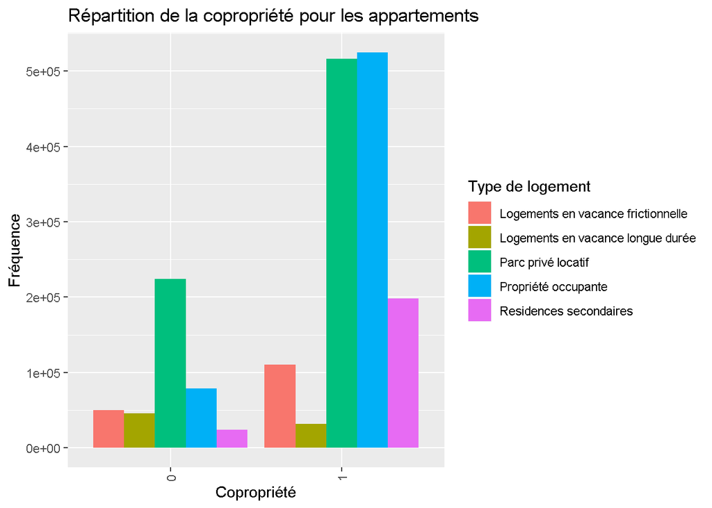

```r
ggplot(data_p %>% filter(maison == 0),aes(as.factor(coprop)))+
  geom_bar(aes(fill=as.factor(comparaison)),position = "dodge")+
  labs(x="Copropriété", y="Fréquence")+
  ggtitle("Répartition de la copropriété pour les appartements")+
  theme(axis.text.x = element_text(angle = 90, vjust=0.5))+
  scale_fill_discrete(name="Type de logement")
```

### 2.3. Date de construction du logement

Certains logements ont l’année zéro pour année de construction. Il doit sûrement s’agir d’erreurs de saisies, et on décide donc de les remplacer par des valeurs manquantes.

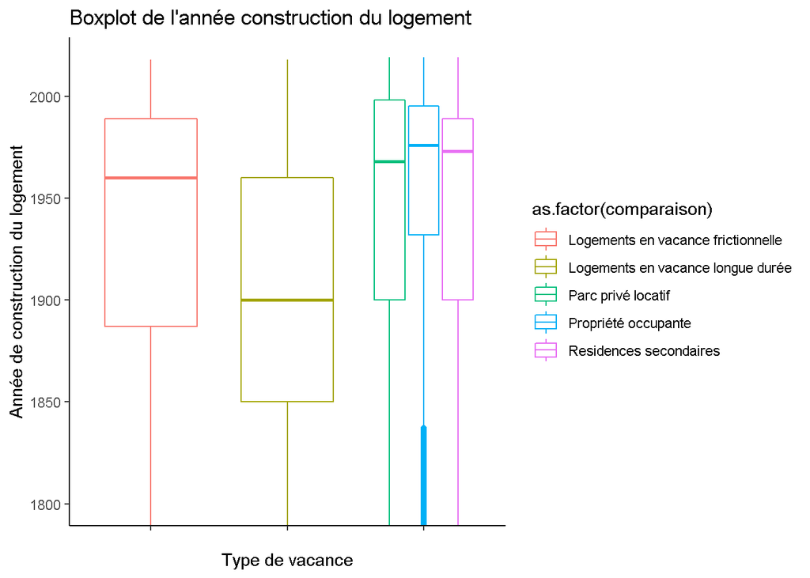

```r
ggplot(data_p,aes(y=ff_jannath, x=as.factor(vacance), colour=as.factor(comparaison)))+
  geom_boxplot(alpha=0.5)+
  theme_classic()+
  labs(x="Type de vacance", y="Année de construction du logement", fill="Vacance de longue durée")+
  ggtitle("Boxplot de l'année construction du logement")+
    scale_fill_discrete(name="Situation du logement")+   scale_x_discrete(labels=c("","","","","","","")) + coord_cartesian(ylim = c(1800, 2018))
```

Sur le diagramme en boîte à moustaches, on observe que la médiane de l’année de construction est plus faible pour le groupe des logements vacants longue durée. Les groupes des logements vacants courte durée, et les logements non vacants semblent présenter une dispersion similaire. On ne représente ici que les logements dont la date de construction est postérieure à 1800 pour se concentrer sur la distribution de la majeure partie des logements.

Le groupe des logements vacants longue durée apparaît comme significativement plus ancien, avec une médiane autour de 1900, alors que tous les autres groupes présentent une médiane postérieure à 1960. Les logements les plus récents, après le groupe des résidus, sont les logements en situation de propriété occupante.

On remarque également que le groupe des résidences secondaires, et le groupe des logements en vacance frictionnelle présentent des années de construction similaires.

```r
print(summary(data_p$ff_jannath))
```

```
##    Min. 1st Qu.  Median    Mean 3rd Qu.    Max.    NA's
##    1200    1900    1972    1944    1993    2019   57567
```

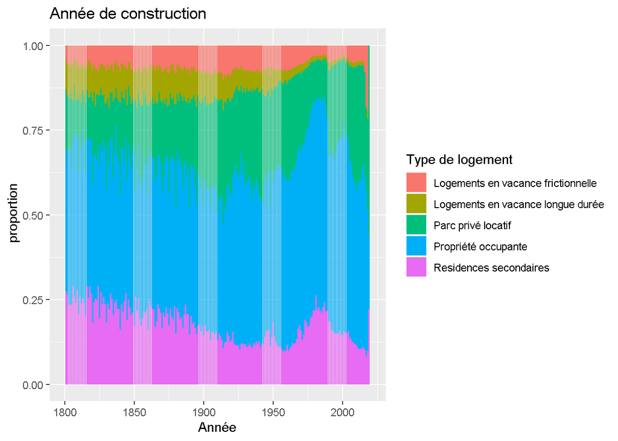

```r
ggplot(data_p,aes(ff_jannath, fill=as.factor(comparaison)))+
  geom_bar(position = "fill")+
  labs(x="Année", y=" proportion")+
  labs(title="Année de construction ")+
    scale_fill_discrete(name="Type de logement")+
    xlim(c(1800,2020))
```

Sur le graphique ci-dessus, on remarque distinctement que la proportion de logements vacants en longue durée diminue quand l’année de construction augmente.

```r
print(summary(data_p$constr_avant_1900[data_p$ld_vacancy == 1]))
```

```
##    Min. 1st Qu.  Median    Mean 3rd Qu.    Max.
##  0.0000  0.0000  0.0000  0.4752  1.0000  1.0000
```

```r
print(summary(data_p$constr_apres_1994[data_p$ld_vacancy == 1]))
```

```
##    Min. 1st Qu.  Median    Mean 3rd Qu.    Max.
##  0.0000  0.0000  0.0000  0.0685  0.0000  1.0000
```

### 2.4. Niveau du confort du logement

```r
summary(data_p$ff_dcapec2)
```

```
##    Min. 1st Qu.  Median    Mean 3rd Qu.    Max.    NA's
##   1.000   5.000   5.000   5.097   5.000   8.000      18
```

On remarque que la grande majorité des logements présents dans la base présente un niveau de confort médian, de niveau 5 ( en effet, le premier quantile, la médiane, et le troisième quantile se trouvent à 5).

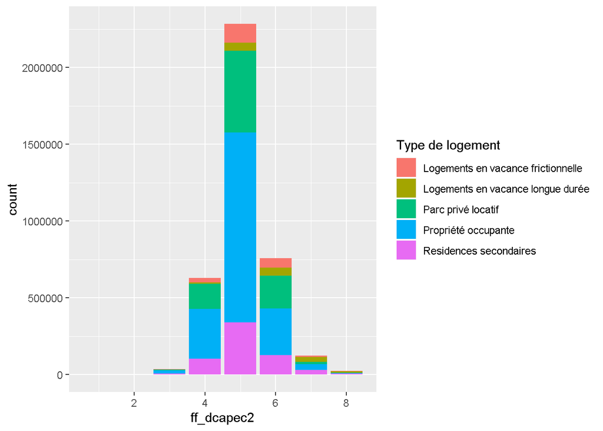

```r
ggplot(data_p)+aes(x= ff_dcapec2) + geom_bar(aes(fill = comparaison)) + scale_fill_discrete(name="Type de logement")
```

Le graphique ci-dessus corrobore ce que l’on vient d’affirmer : la grande majorité des logements présente un niveau de confort médian.

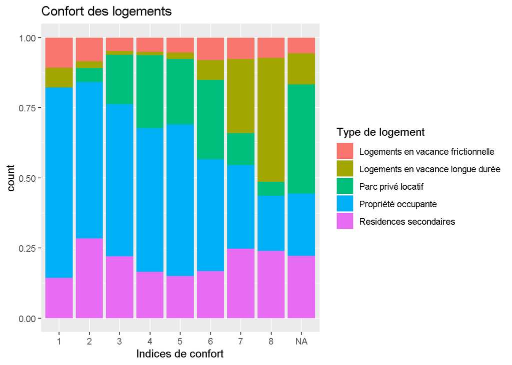

```r
ggplot(data_p,aes(x=as.factor(ff_dcapec2), fill=as.factor(comparaison)))+
  geom_bar(position = "fill")+
  labs(title="Confort des logements", x= "Indices de confort")+
  scale_fill_discrete(name="Type de logement")
```

On remarque distinctement ci-dessus que plus un logement présente un indice de confort élevé (et donc moins il est confortable), plus la proportion de logements vacants longue durée est élevée. La part de logements en situation de vacance frictionnelle semble constante en fonction de l’indice de confort.

Il est à noter que la variable classement cadastral n’est pas réévaluée si le logement ne change pas de propriétaire. Les logements en situation de vacance auront donc davantage tendance à présenter un classement cadastral bas.

```r
print(summary(data_p$confort_1_2_3_4[data_p$ld_vacancy == 1]))
```

```
##    Min. 1st Qu.  Median    Mean 3rd Qu.    Max.
## 0.00000 0.00000 0.00000 0.04951 0.00000 1.00000
```

```r
print(summary(data_p$confort_7_8[data_p$ld_vacancy == 1]))
```

```
##    Min. 1st Qu.  Median    Mean 3rd Qu.    Max.
##  0.0000  0.0000  0.0000  0.2749  1.0000  1.0000
```

28% des logements vacants sont de bas confort, et seuls 5% sont de confort élevé.

Il est à noter que la variable classement cadastral n’est pas réévaluée si le logement ne change pas de propriétaire. Les logements en situation de vacance auront donc davantage tendance à présenter un classement cadastral bas. Pour vérifier ce point, on décide de croiser le classement cadastral et l’année de mutation.

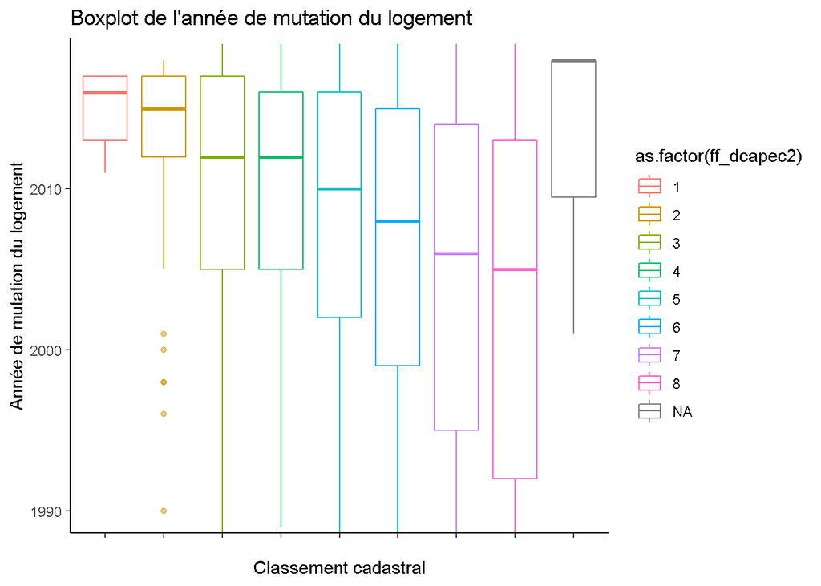

```r
ggplot(data_p,aes(y=annee_mutation, x=as.factor(ff_dcapec2), colour=as.factor(ff_dcapec2)))+
  geom_boxplot(alpha=0.5)+
  theme_classic()+
  labs(x="Classement cadastral", y="Année de mutation du logement", fill="")+
  ggtitle("Boxplot de l'année de mutation du logement")+
    scale_fill_discrete(name="")+   scale_x_discrete(labels=c("","","","","","","","",""))+ coord_cartesian(ylim = c(1990, 2018))
```

Le graphique ci-dessus nous permet de croiser l’année de mutation avec le classement cadastral. On observe très clairement une relation décroissante entre le classement cadastral et l’indice de mutation, ce qui corrobore le fait que les logements qui ne changent pas de propriétaires ne sont pas réévalués. L’information apportée par la variable classement cadastral est donc à considérer en prenant en compte le fait que certains logements anciens ont subi des modifications qui augmentent leur niveau de confort, mais n’ont pas changé de propriétaire et donc de classement cadastral.

On s’intéresse au groupe des logements qui présentent le classement cadastral le plus élevé.

```r
print(nrow(data_p %>% filter(ff_dcapec2 == 1 & ld_vacancy == 1)))
```

```
## [1] 2
```

```r
print(nrow(data_p %>% filter(ff_dcapec2 == 2 & ld_vacancy == 1)))
```

```
## [1] 20
```

La proportion de logements vacants longue durée classés parmi les logements présentant un classement cadastral élevée est négligeable : on dénombre 2 logements vacants longue durée de classement cadastral 1 et 20 de classement cadastral 2. On ne peut donc pas effectuer davantage de statistiques sur ce groupe.

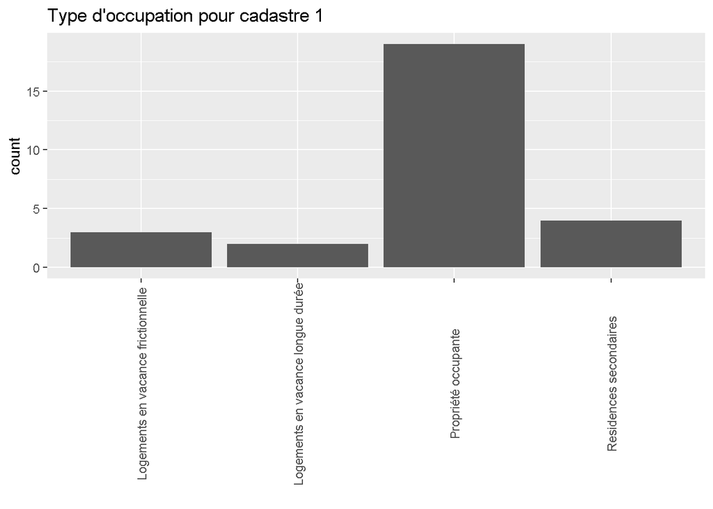

```r
ggplot(data_p %>% filter(ff_dcapec2 == 1),aes(x=as.factor(comparaison))) + geom_bar(position = "dodge")+
labs(title="Type d'occupation pour cadastre 1 ", x= "") +
  theme(axis.text.x = element_text(angle = 90, vjust=0.5)) + theme(legend.position="none")
```

On suppose également que l’année de construction du logement et le classement cadastral sont des variables corrélées. On réalise donc à nouveau un diagramme en boîte à moustaches.

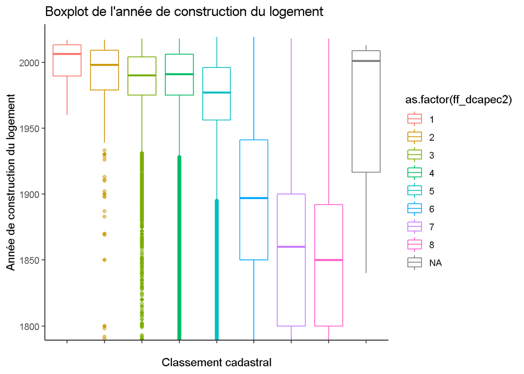

```r
ggplot(data_p,aes(y=ff_jannath, x=as.factor(ff_dcapec2), colour=as.factor(ff_dcapec2)))+
  geom_boxplot(alpha=0.5)+
  theme_classic()+
  labs(x="Classement cadastral", y="Année de construction du logement", fill="")+
  ggtitle("Boxplot de l'année de construction du logement")+
    scale_fill_discrete(name="")+   scale_x_discrete(labels=c("","","","","","","","",""))+ coord_cartesian(ylim = c(1800, 2018))
```

On cherche également à observer la corrélation entre l’année de mutation et l’année de construction. Les logements les plus anciens ont-ils tendance à présenter des années de mutations les plus anciennes?

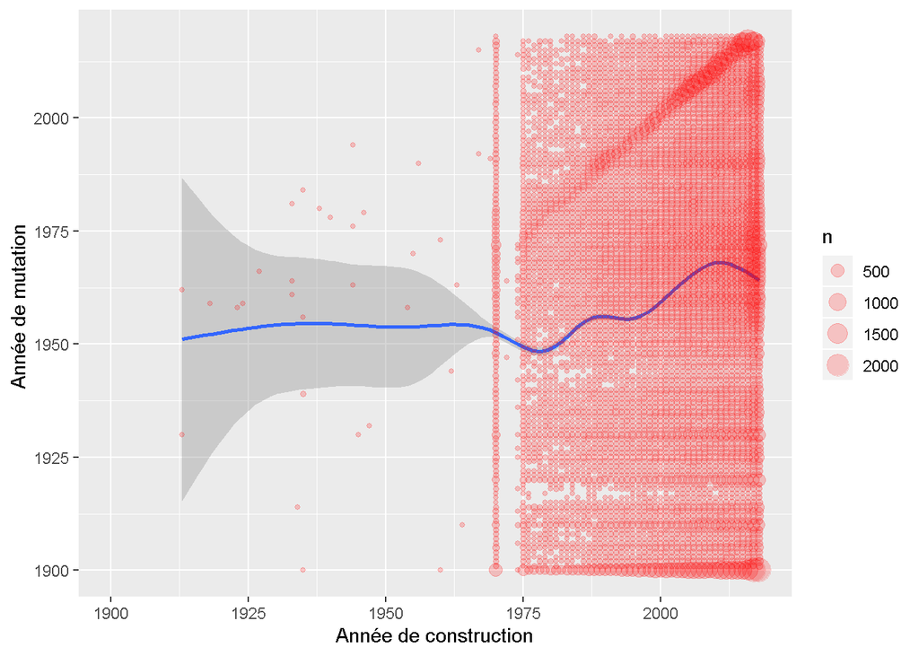

```r
ggplot(data_p) +
  aes(x = annee_mutation, y = ff_jannath) +
  geom_smooth() +
  geom_count(colour = "red", alpha = .2) +
  xlab("Année de construction") +
  ylab("Année de mutation ") + xlim(c(1900,2018)) + ylim(c(1900, 2018))
```

Le lien entre année de construction et année de mutation ne semble pas très clair à la lecture de ce graphique. On procède donc à un test de corrélation de Spearman (puisqu’on ne fait pas l’hypothèse que la distribution suive une loi normale).

```r
cor.test(data_p$ff_jannath, data_p$annee_mutation, method="spearman")
```

```
##
##  Spearman's rank correlation rho
##
## data:  data_p$ff_jannath and data_p$annee_mutation
## S = 7.4721e+15, p-value < 2.2e-16
## alternative hypothesis: true rho is not equal to 0
## sample estimates:
##       rho
## 0.1127277
```

La corrélation entre l’année de mutation et l’année de construction est positive d’après le test de Spearman.

### 2.5. Nombre de baignoires

```r
summary(data_p$ff_dnbbai)
```

```
##    Min. 1st Qu.  Median    Mean 3rd Qu.    Max.
##  0.0000  0.0000  1.0000  0.6765  1.0000 21.0000
```

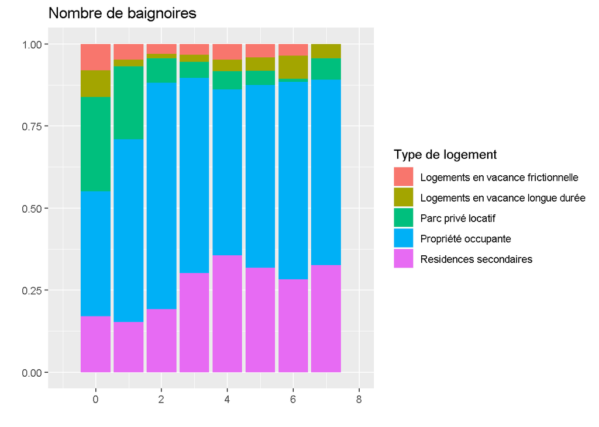

```r
ggplot(data_p,aes(ff_dnbbai, fill=as.factor(comparaison)))+
  geom_bar(position = "fill") +
  labs(title="Nombre de baignoires", x = "", y ="")+
  scale_fill_discrete(name="Type de logement") +
  xlim(c(-1,8))
```

On remarque que la proportion de logements vacants longue durée ne semble pas montrer de tendance claire en fonction du nombre de baignoires dont dispose un logement. Cependant, il est à noter que seule une partie extrêmement réduite de la base de logements compte plus de 6 baignoires.

On décide de recoder la variable baignoire, en isolant les logements qui ne présentent aucune baignoire, et ceux qui en comptent plus de 3.

```r
print(summary(data_p$abs_baign[data_p$ld_vacancy == 1]))
```

```
##    Min. 1st Qu.  Median    Mean 3rd Qu.    Max.
##  0.0000  0.0000  1.0000  0.6853  1.0000  1.0000
```

```r
print(sum(data_p$abs_baign)/nrow(data_p))
```

```
## [1] 0.3450422
```

```r
print(summary(data_p$nb_baign_sup_3[data_p$ld_vacancy == 1]))
```

```
##      Min.   1st Qu.    Median      Mean   3rd Qu.      Max.
## 0.0000000 0.0000000 0.0000000 0.0009486 0.0000000 1.0000000
```

```r
print(sum(data_p$nb_baign_sup_3)/nrow(data_p))
```

```
## [1] 0.001468663
```

```r
print(summary(data_p$ff_dnbbai[data_p$ld_vacancy == 1]))
```

```
##    Min. 1st Qu.  Median    Mean 3rd Qu.    Max.
##  0.0000  0.0000  0.0000  0.3232  1.0000 12.0000
```

### 2.6. Nombre de douches

```r
summary(data_p$ff_dnbdou)
```

```
##    Min. 1st Qu.  Median    Mean 3rd Qu.    Max.
##  0.0000  0.0000  0.0000  0.5004  1.0000 44.0000
```

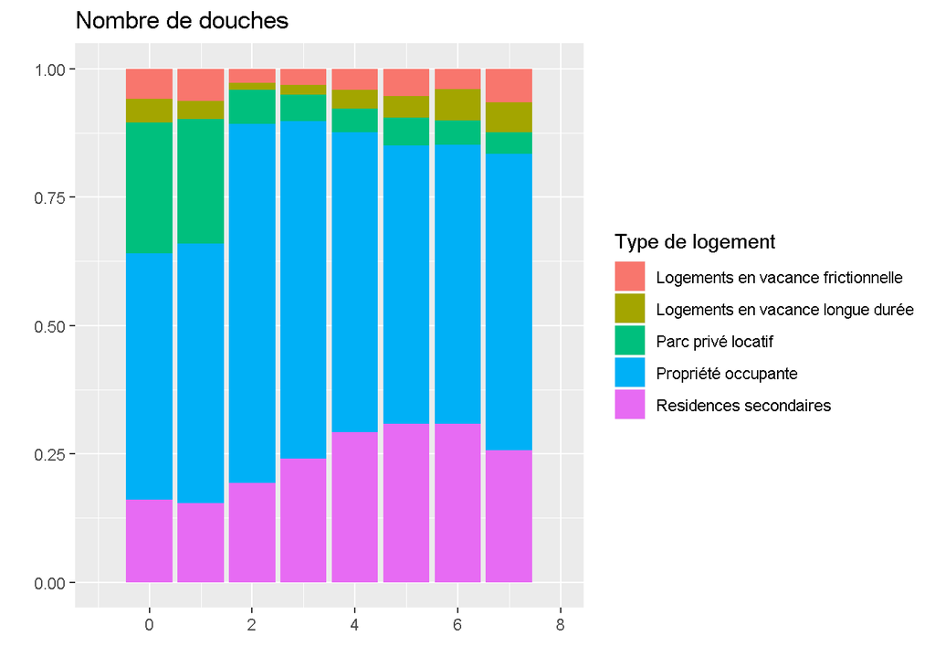

```r
ggplot(data_p,aes(ff_dnbdou, fill=as.factor(comparaison)))+
  geom_bar(position = "fill")+
  labs(title="Nombre de douches", x ="", y = "")+
  scale_fill_discrete(name="Type de logement")+
  xlim(c(-1,8))
```

A la lecture de ce graphique, il ne semble pas émerger de tendance claire pour la proportion de logements vacants selon le nombre de douches par logements (comme c’était déjà le cas pour le nombre de baignoires).

```r
print(summary(data_p$abs_douche[data_p$ld_vacancy == 1]))
```

```
##    Min. 1st Qu.  Median    Mean 3rd Qu.    Max.
##  0.0000  0.0000  1.0000  0.6229  1.0000  1.0000
```

```r
print(sum(data_p$abs_douche)/nrow(data_p))
```

```
## [1] 0.5445727
```

```r
print(summary(data_p$nb_douche_sup_3[data_p$ld_vacancy == 1]))
```

```
##     Min.  1st Qu.   Median     Mean  3rd Qu.     Max.
## 0.000000 0.000000 0.000000 0.002782 0.000000 1.000000
```

```r
print(sum(data_p$nb_douche_sup_3)/nrow(data_p))
```

```
## [1] 0.004562058
```

```r
print(summary(data_p$ff_dnbdou[data_p$ld_vacancy == 1]))
```

```
##    Min. 1st Qu.  Median    Mean 3rd Qu.    Max.
##  0.0000  0.0000  0.0000  0.3959  1.0000 10.0000
```

62% des logements vacants ne présentent pas de douches, contre 54% des logements dans le reste de la base. Seuls 0.3% des logements vacants longue durée sont comptés parmi ceux qui présentent un nombre de douche élevé, contre 0.48% dans le reste de la base. Il ne semble pas émerger de tendance claire pour les logements vacants au regard du nombre de douches qu’ils présentent.

### 2.7. Nombre de WC

```r
summary(data_p$ff_dnbwc)
```

```
##    Min. 1st Qu.  Median    Mean 3rd Qu.    Max.
##   0.000   1.000   1.000   1.178   1.000  31.000
```

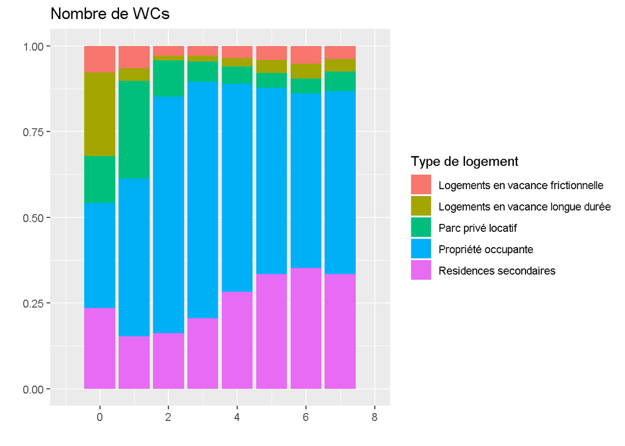

```r
ggplot(data_p,aes(ff_dnbwc, fill=as.factor(comparaison), freq = TRUE))+
  geom_bar(position = "fill")+
  labs(title="Nombre de WCs", x ="", y = "")+
  scale_fill_discrete(name="Type de logement") +
  xlim(c(-1,8))
```

La proportion de logements vacants longue durée est maximale pour les logements qui en comptent aucun WC.

```r
print(summary(data_p$abs_wc[data_p$ld_vacancy == 1]))
```

```
##    Min. 1st Qu.  Median    Mean 3rd Qu.    Max.
##  0.0000  0.0000  0.0000  0.2732  1.0000  1.0000
```

```r
print(sum(data_p$abs_wc)/nrow(data_p))
```

```
## [1] 0.04558533
```

```r
print(summary(data_p$nb_wc_sup_3[data_p$ld_vacancy == 1]))
```

```
##     Min.  1st Qu.   Median     Mean  3rd Qu.     Max.
## 0.000000 0.000000 0.000000 0.008277 0.000000 1.000000
```

```r
print(sum(data_p$nb_wc_sup_3)/nrow(data_p))
```

```
## [1] 0.01881885
```

```r
print(summary(data_p$ff_dnbwc[data_p$ld_vacancy == 1]))
```

```
##    Min. 1st Qu.  Median    Mean 3rd Qu.    Max.
##  0.0000  0.0000  1.0000  0.8064  1.0000 22.0000
```

27% des logements vacants longue durée ne présentent pas de WC, contre 4,6% dans le reste de la base. Seuls 0.8% des logements vacants longue durée présentent plus de 3 WCs, contre 1,9% dans le reste de la base. La moyenne de WC par logements vacants longue durée est 0.81 ( inférieure à 1), alors que la moyenne de WC par logements dans le reste de la base est de 1,18 (supérieure à 1). A la lecture de ces premières statistiques, le nombre de WCs semble donc une covariable pertinente pour expliquer la vacance longue durée des logements.

```r
print(summary(data_p$abs_wc[data_p$ff_npiece_p2 <= 1]))
```

```
##    Min. 1st Qu.  Median    Mean 3rd Qu.    Max.
##  0.0000  0.0000  0.0000  0.1525  0.0000  1.0000
```

```r
print(summary(data_p$abs_wc[data_p$ff_stoth<= 9]))
```

```
##    Min. 1st Qu.  Median    Mean 3rd Qu.    Max.
##   0.000   1.000   1.000   0.751   1.000   1.000
```

```r
print(sum(data_p$abs_wc[data_p$ff_stoth<= 9])/ sum(data_p$abs_wc))
```

```
## [1] 0.008337409
```

```r
print(sum(data_p$abs_wc[data_p$ff_npiece_p2<= 1])/ sum(data_p$abs_wc))
```

```
## [1] 0.332484
```

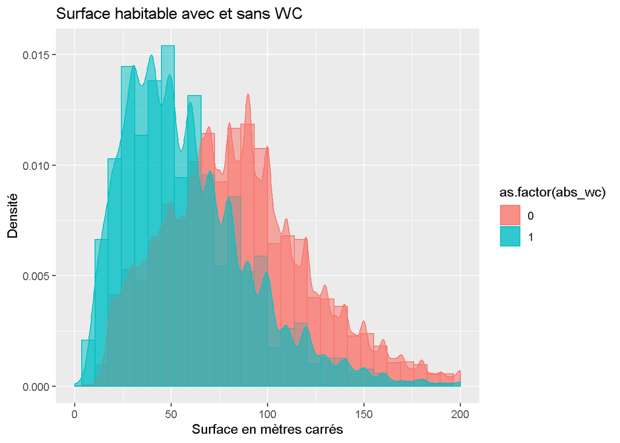

```r
ggplot(data_p, aes(x = ff_stoth, color= as.factor(abs_wc), fill= as.factor(abs_wc)))+
  geom_histogram(aes(y=..density..), position="identity", alpha=0.5)+
  geom_density(alpha=0.6)+
  labs(title="Surface habitable avec et sans WC", x ='Surface en mètres carrés', y = "Densité")+
  xlim(c(0,200))
```

```r
print(sum(data_p$nosani[data_p$ff_npiece_p2<= 1])/ sum(data_p$nosani))
```

```
## [1] 0.2902511
```

```r
print(sum(data_p$abs_wc_sani)/nrow(data_p))
```

```
## [1] 0
```

```r
print(sum(data_p$abs_wc)/nrow(data_p))
```

```
## [1] 0.04558533
```

```r
print(sum(data_p$nosani)/nrow(data_p))
```

```
## [1] 0.0763194
```

### 2.8. Surface habitable du logement

```r
summary(data_p$ff_stoth)
```

```
##    Min. 1st Qu.  Median    Mean 3rd Qu.    Max.
##    1.00   56.00   81.00   85.58  107.00 2987.00
```

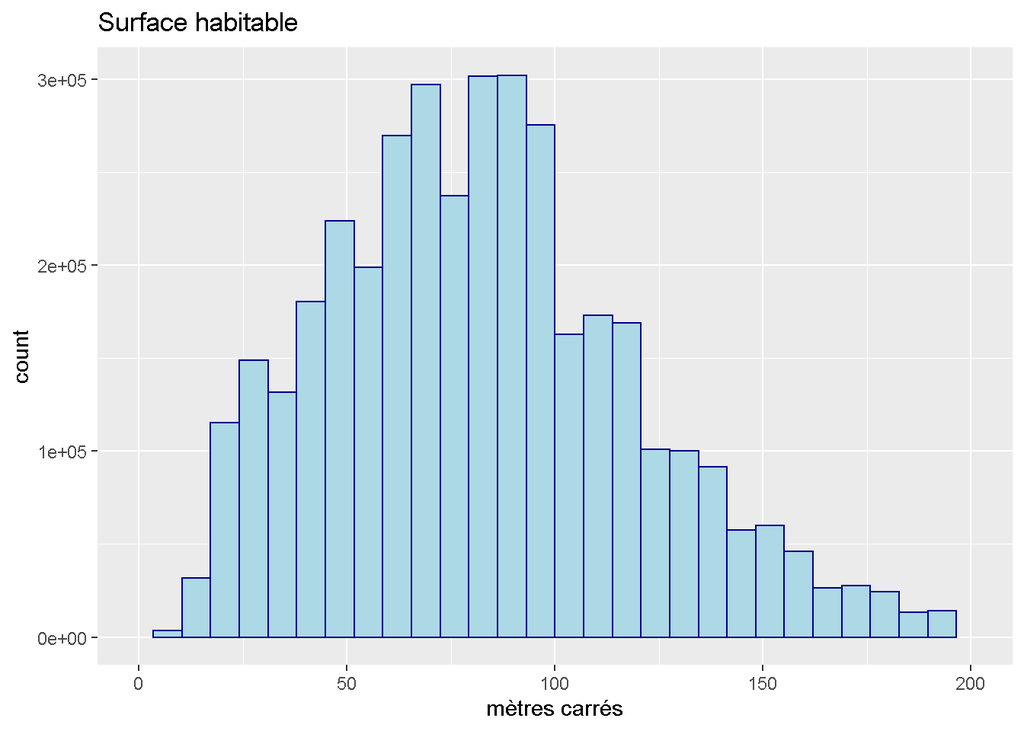

```r
ggplot(data_p, aes(x= ff_stoth), bins = 50 )+
  geom_histogram(color="darkblue", fill="lightblue") +
  labs(title="Surface habitable ")+
  xlab("mètres carrés")+
  xlim(c(0,200))
```

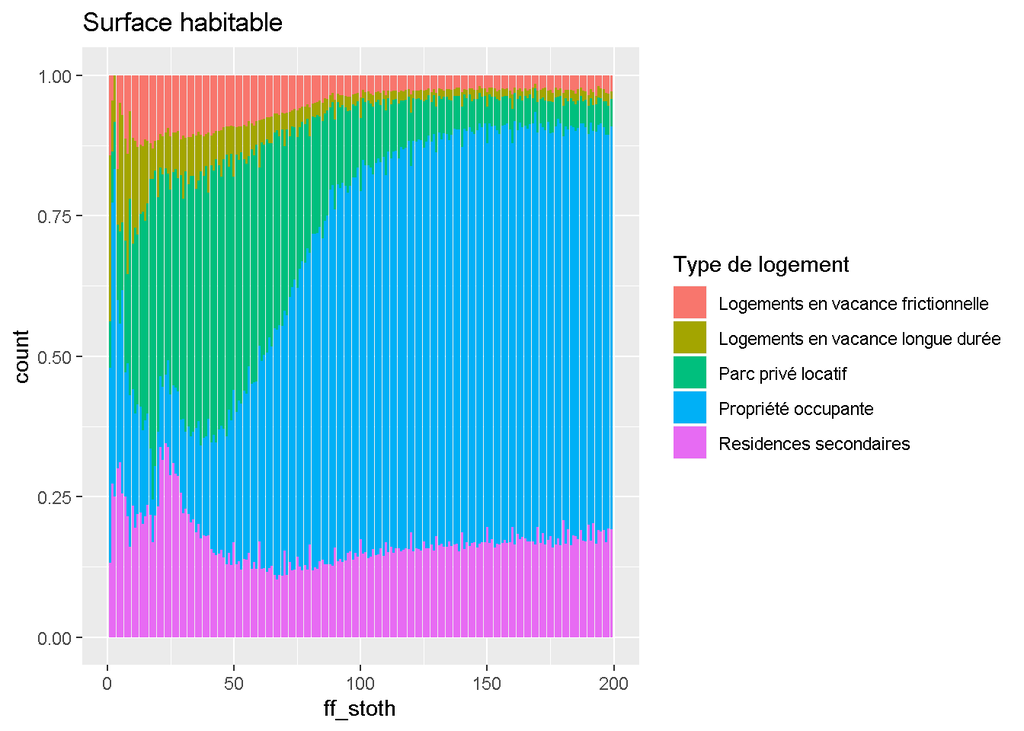

```r
ggplot(data_p,aes(ff_stoth, fill=as.factor(comparaison)))+
  geom_bar(position = "fill")+
  labs(title="Surface habitable")+
  scale_fill_discrete(name="Type de logement")+
  xlim(c(0, 200))
```

La proportion de logements vacants longue durée est décroissante en fonction de la surface habitable en mètres carrés.

On sépare les logements qui comptent moins de 25 mètres carrés, et présentent donc une petite surface des autres.On sépare également les logements de plus de 100 mètres carrés des autres.

```r
print(summary(data_p$surf_inf_25[data_p$ld_vacancy == 1]))
```

```
##    Min. 1st Qu.  Median    Mean 3rd Qu.    Max.
## 0.00000 0.00000 0.00000 0.07942 0.00000 1.00000
```

```r
print(summary(data_p$surf_sup_100[data_p$ld_vacancy == 1]))
```

```
##    Min. 1st Qu.  Median    Mean 3rd Qu.    Max.
##  0.0000  0.0000  0.0000  0.1404  0.0000  1.0000
```

8% des logements vacants longue durée sont comptabilisés comme présentant une petite surface, alors que seuls 14% présentent une grande surface.

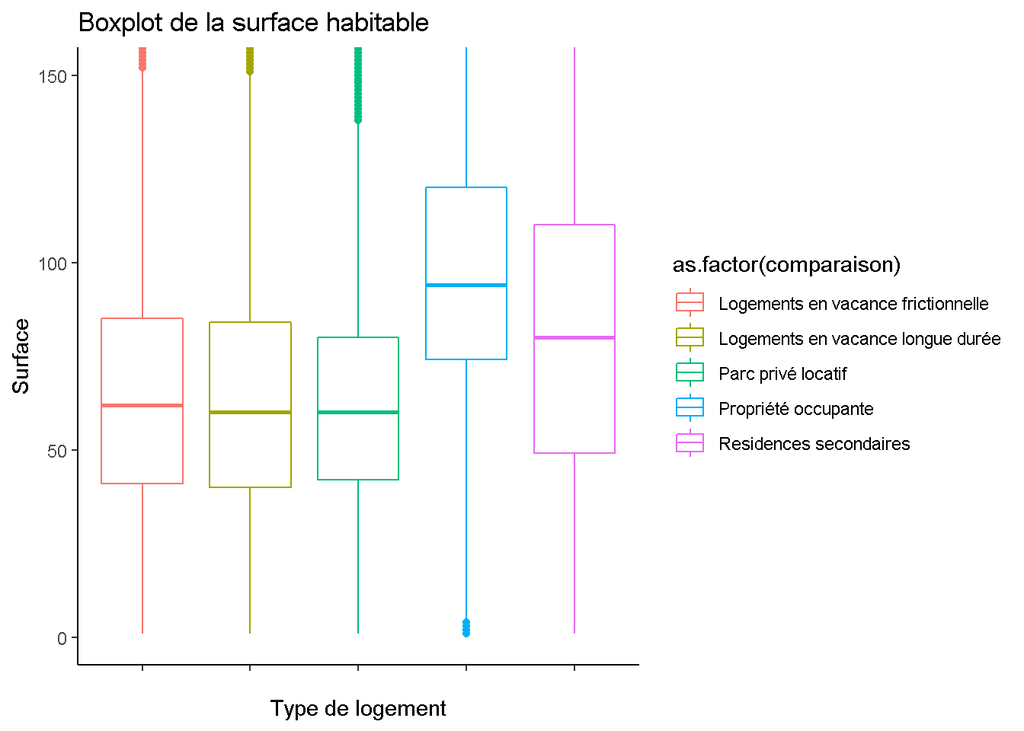

```r
ggplot(data_p,aes(y = ff_stoth, x=as.factor(comparaison), colour=as.factor(comparaison)))+
  geom_boxplot(alpha=0.5)+
  theme_classic()+
  labs(x="Type de logement", y="Surface", fill="")+
  ggtitle("Boxplot de la surface habitable")+
    scale_fill_discrete(name="")+   scale_x_discrete(labels=c("","","", "","","",""))+ coord_cartesian(ylim = c(0,150))
```

### 2.9 Surface par pièces

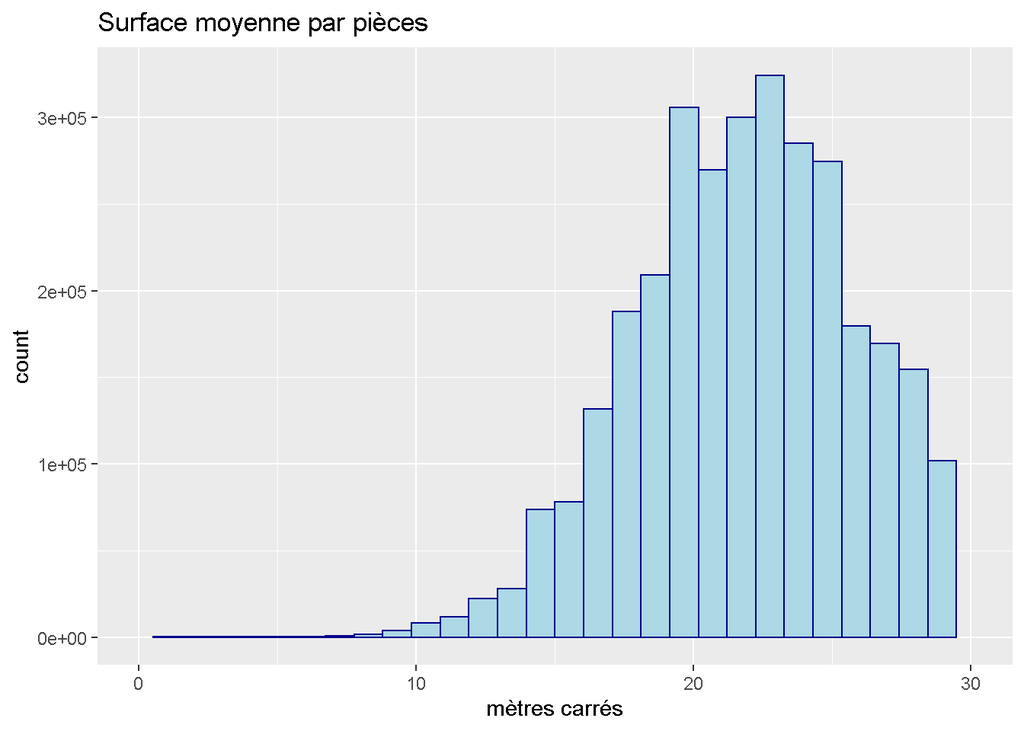

```r
ggplot(data_p, aes(x= surf_pp), bins = 50 )+
  geom_histogram(color="darkblue", fill="lightblue") +
  labs(title="Surface moyenne par pièces ")+
  xlab("mètres carrés")+
  xlim(c(0,30))
```

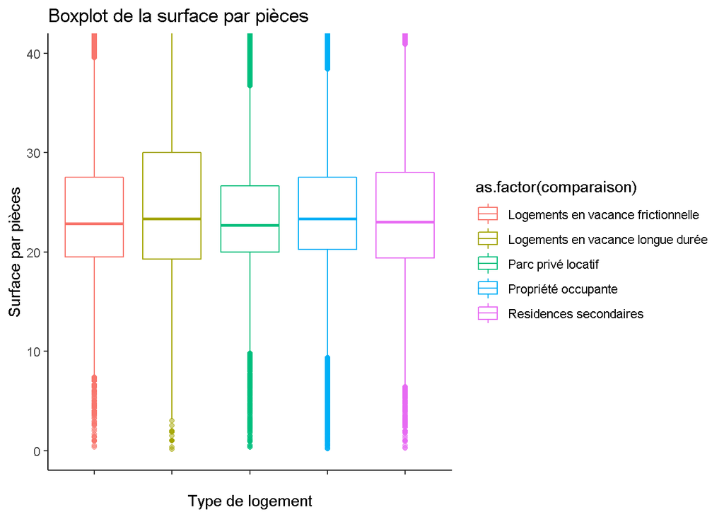

```r
ggplot(data_p,aes(y=surf_pp, x=as.factor(comparaison), colour=as.factor(comparaison)))+
  geom_boxplot(alpha=0.5)+
  theme_classic()+
  labs(x="Type de logement", y="Surface par pièces", fill="")+
  ggtitle("Boxplot de la surface par pièces")+
    scale_fill_discrete(name="")+   scale_x_discrete(labels=c("","","","","",""))+ coord_cartesian(ylim = c(0,40))
```

Le graphique ci-dessus nous permet d’observer que les différents groupes de logement sont très similaires au regard de la surface par pièces. La surface par pièce nous semble donc une covariable peu pertinente pour expliquer les déterminants de la vacance longue durée.

### 2.10 Dépendance du logement

```r
print(summary(data_p$dependance))
```

```
##    Min. 1st Qu.  Median    Mean 3rd Qu.    Max.
##    0.00    4.00   20.00   44.13   69.00 2710.00
```

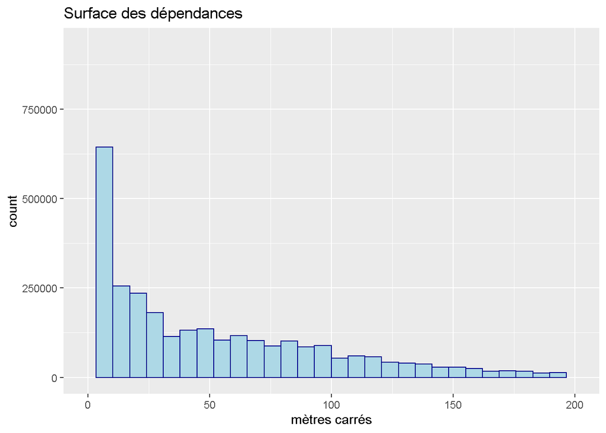

```r
ggplot(data_p, aes(x= dependance), bins = 50 )+
  geom_histogram(color="darkblue", fill="lightblue") +
  labs(title="Surface des dépendances ") +
        xlab("mètres carrés") + xlim(c(0,200))
```

On considère que l’information importante présente dans cette variable est la présence ou non d’une dépendance.

```r
print(summary(data_p$existence_dependance))
```

```
##    Min. 1st Qu.  Median    Mean 3rd Qu.    Max.
##  0.0000  1.0000  1.0000  0.8105  1.0000  1.0000
```

```r
print(summary(data_p$existence_dependance[data_p$ld_vacancy == 1]))
```

```
##    Min. 1st Qu.  Median    Mean 3rd Qu.    Max.
##  0.0000  0.0000  1.0000  0.6441  1.0000  1.0000
```

80% des logements disposent d’une dépendance (on une surface des parties d’évaluation supérieure à la surface des pièces d’habitation) dans l’ensemble de la base. Pour les logements vacants longue durée, seuls 64% disposent d’une dépendance.

On crée également une variable pour séparer les logements qui disposent d’une grande dépendance, en s’appuyant sur la valeur du 3ème quantile.

```r
print(summary(data_p$dep_sup_67))
```

```
##    Min. 1st Qu.  Median    Mean 3rd Qu.    Max.
##  0.0000  0.0000  0.0000  0.2484  0.0000  1.0000
```

```r
print(summary(data_p$dep_sup_67[data_p$ld_vacancy == 1]))
```

```
##    Min. 1st Qu.  Median    Mean 3rd Qu.    Max.
##  0.0000  0.0000  0.0000  0.1712  0.0000  1.0000
```

On remarque que seuls 17% des logements vacants présentent une dépendance de plus de 67 mètres carrés.

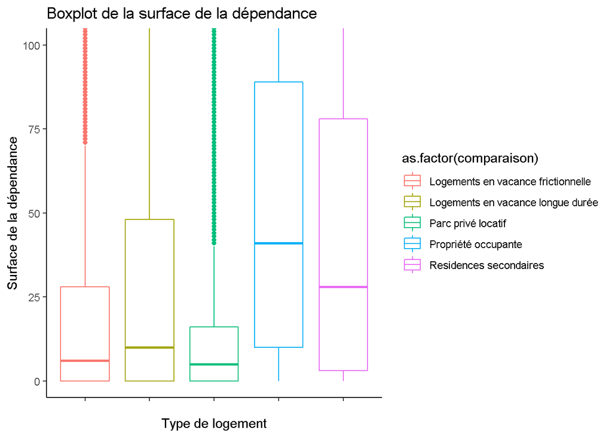

```r
ggplot(data_p,aes(y=dependance, x=as.factor(comparaison), colour=as.factor(comparaison)))+
  geom_boxplot(alpha=0.5)+
  theme_classic()+
  labs(x="Type de logement", y="Surface de la dépendance", fill="")+
  ggtitle("Boxplot de la surface de la dépendance")+
    scale_fill_discrete(name="")+   scale_x_discrete(labels=c("","","","","",""))+ coord_cartesian(ylim = c(0,100))
```

On constate sur le graphique ci-dessus que les logements vacants et les logements du parc privé locatif se distinguent du groupe des logements occupés par leurs propriétaires et du groupe des résidences secondaires, qui présentent des dépendances de taille plus importante. Ce résultat semble à mettre en parallèle avec le fait que les logements vacants et le parc locatif sont davantage des appartements que les autres groupes, qui présentent de fait des dépendances plus petites.

Le fichier étudié ne recense pas le type de dépendance que présente le logement. On cherche néanmoins à étudier la surface de la dépendance pour les maisons et pour les appartements.

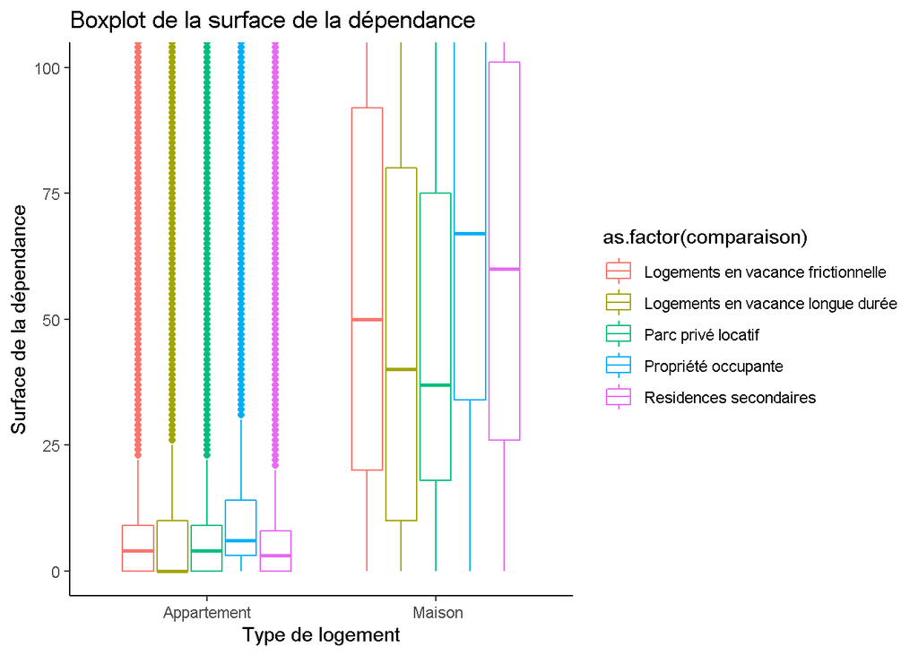

```r
ggplot(data_p,aes(y=dependance, x=as.factor(maison), colour=as.factor(comparaison)))+
  geom_boxplot(alpha=0.5)+
  theme_classic()+
  labs(x="Type de logement", y="Surface de la dépendance", fill="")+
  ggtitle("Boxplot de la surface de la dépendance")+
    scale_fill_discrete(name="")+   scale_x_discrete(labels=c("Appartement"," Maison"))+ coord_cartesian(ylim = c(0,100))
```

On constate que les appartements et les maisons présentent des distributions similaires : les logements occupés par leurs propriétaires présentent les dépendances les plus grandes, et le reste des groupes affiche une distribution similaire.

On remarque tout de même que la moitié des appartements en situation de vacance longue durée ne présente pas de dépendance (c’est le groupe dont la médiane est le plus faible).

### 2.10. Nombre de pièces

```r
sum(data_p$ff_npiece_p2 == 0)
```

```
## [1] 7680
```

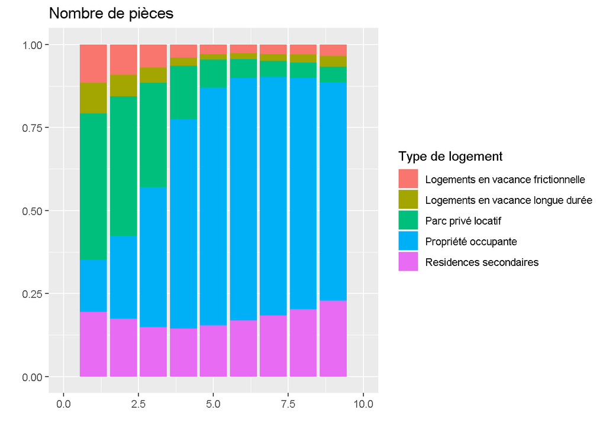

```r
ggplot(data_p,aes(ff_npiece_p2, fill=as.factor(comparaison), freq = TRUE))+
  geom_bar(position = "fill")+
  labs(title="Nombre de pièces", x = "", y = "")+
  scale_fill_discrete(name="Type de logement") +
  xlim(c(0,10))
```

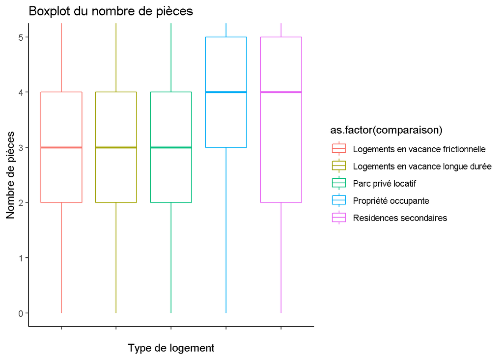

```r
ggplot(data_p,aes(y = ff_npiece_p2, x=as.factor(comparaison), colour=as.factor(comparaison)))+
  geom_boxplot(alpha=0.5)+
  theme_classic()+
  labs(x="Type de logement", y="Nombre de pièces", fill="")+
  ggtitle("Boxplot du nombre de pièces")+
    scale_fill_discrete(name="")+   scale_x_discrete(labels=c("","","", "","","",""))+ coord_cartesian(ylim = c(0,5))
```

Par ailleurs, comme on a procédé précédemment, on crée deux autres facteurs, qui permettent de retrouver les logements qui ont un grand nombre de pièces, et ceux qui en présentent peu.

```r
print(sum(data_p$zero_piece[data_p$ld_vacancy == 1]))
```

```
## [1] 1675
```

```r
print(sum(data_p$zero_piece[data_p$ff_stoth <= 9])/ sum(data_p$zero_piece))
```

```
## [1] 0
```

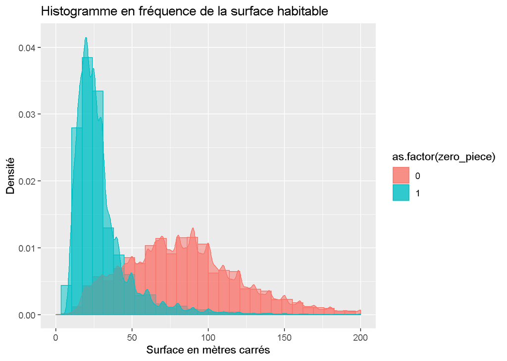

```r
ggplot(data_p, aes(x = ff_stoth, color= as.factor(zero_piece), fill= as.factor(zero_piece)))+
  geom_histogram(aes(y=..density..), position="identity", alpha=0.5)+
  geom_density(alpha=0.6)+
  labs(title="Histogramme en fréquence de la surface habitable", x ='Surface en mètres carrés', y = "Densité")+
  xlim(c(0,200))
```

On remarque ici que les biens sont comptabilisés comme comptant zéro pièces présentent une surface en mètres carrés plus faible.

```r
print(summary(data_p$nb_piece_inf_1[data_p$ld_vacancy == 1]))
```

```
##    Min. 1st Qu.  Median    Mean 3rd Qu.    Max.
##  0.0000  0.0000  0.0000  0.2296  0.0000  1.0000
```

```r
print(summary(data_p$nb_piece_sup_5[data_p$ld_vacancy == 1]))
```

```
##    Min. 1st Qu.  Median    Mean 3rd Qu.    Max.
##  0.0000  0.0000  0.0000  0.1088  0.0000  1.0000
```

```r
quantile(data_p$ff_npiece_p2, 0.25, na.rm=TRUE)
```

```
## 25%
##   2
```

```r
quantile(data_p$ff_npiece_p2, 0.75, na.rm=TRUE)
```

```
## 75%
##   4
```

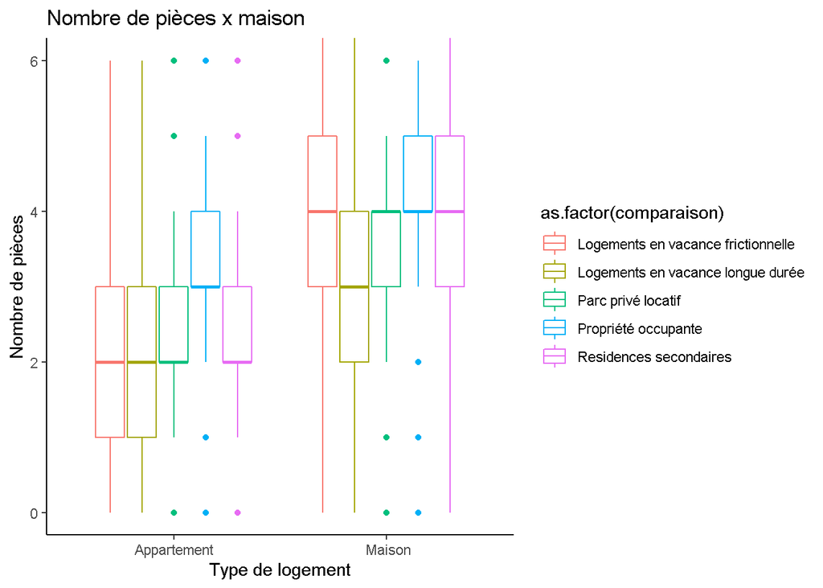

```r
ggplot(data_p,aes(y=ff_npiece_p2, x=as.factor(maison), colour=as.factor(comparaison)))+
  geom_boxplot(alpha=0.5)+
  theme_classic()+
  labs(x="Type de logement", y="Nombre de pièces", fill="")+
  ggtitle("Nombre de pièces x maison")+
    scale_fill_discrete(name="")+   scale_x_discrete(labels=c("Appartement"," Maison"))+ coord_cartesian(ylim = c(0,6))
```

## 3. Statistiques sur les caractéristiques propres aux logements vacants

### 3.1. Taxes TLV (en zones tendues)

Dans certaines communes, les logements vacants sont soumis à une taxe. On s’intéresse dans un premier temps à la taxe TLV, qui n’entre en vigueur que dans les zones tendues

```r
data_p$txtlv<-as.character(data_p$txtlv)
data_p$thlv<-ifelse(data_p$txtlv=="   1"|data_p$txtlv=="   2"|data_p$txtlv=="   3"|data_p$txtlv=="   4"|data_p$txtlv=="   5"|data_p$txtlv=="   6"|data_p$txtlv=="   7"|data_p$txtlv=="   8"|data_p$txtlv=="   9"|data_p$txtlv=="  10"|data_p$txtlv=="  11"|data_p$txtlv=="  12",data_p$txtlv,0)

data_p$tlv<-ifelse(grepl("12,5",data_p$txtlv),1,ifelse(grepl("25",data_p$txtlv),2,0))
data_p$thlv <- as.numeric(data_p$thlv)
```

```r
data_p$tlv <- ifelse(data_p$tlv >= 1, 1, 0)
data_p$tlv <- na.fill(data_p$tlv, 0)

summary(data_p$tlv[data_p$ld_vacancy == 1])
```

```
##    Min. 1st Qu.  Median    Mean 3rd Qu.    Max.
## 0.00000 0.00000 0.00000 0.06314 0.00000 1.00000
```

A la lecture de ces tableaux, on constate que 6.3% des logements vacants longue durée sont soumis à une taxe TLV.

### 3.2. Taxes THLV (en zones non tendues)

La THLV est une taxe d’habitation sur les logements vacants dans les zones non tendues.

```r
data_p$thlv <- ifelse(data_p$thlv > 0, 1, 0)
data_p$thlv <- na.fill(data_p$thlv, 0)
print(summary(data_p$thlv))
```

```
##     Min.  1st Qu.   Median     Mean  3rd Qu.     Max.
## 0.000000 0.000000 0.000000 0.004636 0.000000 1.000000
```

```r
print(summary(data_p$thlv[data_p$ld_vacancy == 1]))
```

```
##    Min. 1st Qu.  Median    Mean 3rd Qu.    Max.
##  0.0000  0.0000  0.0000  0.1138  0.0000  1.0000
```

```r
summary(data_p$anrefthlv)
```

```
##    Min. 1st Qu.  Median    Mean 3rd Qu.    Max.    NA's
##    1979    2015    2018    2016    2018    2020 3471698
```

Les années de référence de la taxe THLV sont entre 1979 et 2020.

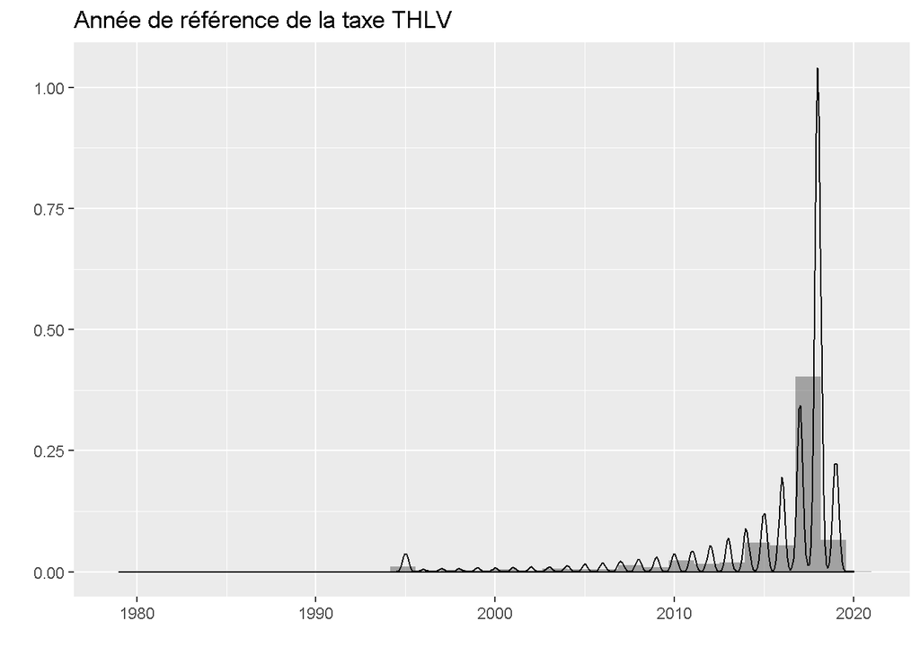

```r
ggplot(data_p, aes(x=anrefthlv))+
  geom_histogram(aes(y=..density..), position="identity", alpha=0.5)+
  geom_density(alpha=0.6)+
  labs(title="Année de référence de la taxe THLV", x = "", y = "")
```

On cherche à séparer les logements qui ont une année de référence ancienne pour la taxe THLV, de ce qui ont une année de référence plus récente. Pour ce faire, on s’appuie sur les quantiles comme on l’a fait pour les années de construction des logements.

```r
data_p$annee_ref_thlv_ancienne <-ifelse(data_p$anrefthlv < quantile(data_p$anrefthlv, 0.25, na.rm=TRUE), 1, 0  )
data_p$annee_ref_thlv_ancienne <- na.fill(data_p$annee_ref_thlv_ancienne,0)

data_p$annee_ref_thlv_recente <-ifelse(data_p$anrefthlv > quantile(data_p$anrefthlv, 0.75, na.rm=TRUE), 1, 0  )
data_p$annee_ref_thlv_recente <- na.fill(data_p$annee_ref_thlv_recente,0)

summary(data_p$annee_ref_thlv_ancienne)
```

```
##    Min. 1st Qu.  Median    Mean 3rd Qu.    Max.
## 0.00000 0.00000 0.00000 0.02109 0.00000 1.00000
```

```r
summary(data_p$annee_ref_thlv_recente)
```

```
##     Min.  1st Qu.   Median     Mean  3rd Qu.     Max.
## 0.000000 0.000000 0.000000 0.009277 0.000000 1.000000
```

### 3.3. Valeur actualisée du logement, revalorisée à l’année 2019

La valeur actualisée du logement est renseignée dans notre base pour les logements en situation de vacance longue durée, et pour la quasi-totalité des logements vacants (0.047% de données manquantes).

```r
summary(data_p$vl_2019[data_p$vacancy == 1])
```

```
##    Min. 1st Qu.  Median    Mean 3rd Qu.    Max.    NA's
##       6    1311    2069    2423    3131   93746     183
```

```r
summary(data_p$vl_2019[data_p$ld_vacancy == 1])
```

```
##    Min. 1st Qu.  Median    Mean 3rd Qu.    Max.
##       6     879    1519    1874    2424   80570
```

```r
183/sum(data_p$vacancy == 1)
```

```
## [1] 0.000474419
```

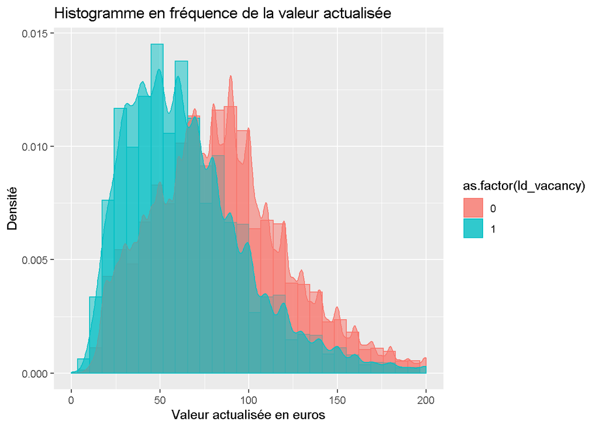

```r
ggplot(data_p, aes(x = ff_stoth, color= as.factor(ld_vacancy), fill= as.factor(ld_vacancy))) +
  geom_histogram(aes(y=..density..), position="identity", alpha=0.5)+
  geom_density(alpha=0.6)+
  labs(title="Histogramme en fréquence de la valeur actualisée", x ='Valeur actualisée en euros', y = "Densité")+
  xlim(c(0,200))
```

### 3.4. Début de la vacance

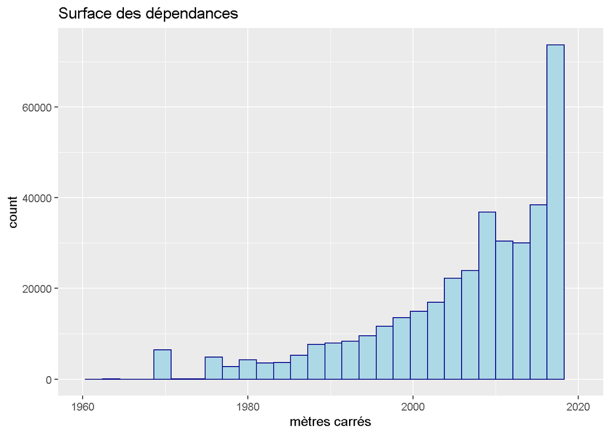

```r
ggplot(data_p, aes(x= annee_mutation), bins = 50 )+
  geom_histogram(color="darkblue", fill="lightblue")+
  labs(title="Surface des dépendances ")+
  xlab("mètres carrés")+
  xlim(c(1960,2020))
```

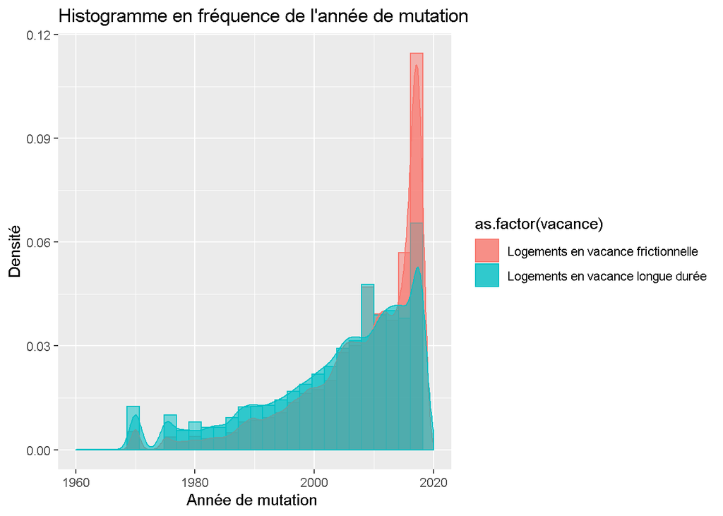

```r
ggplot(data_p, aes(x = annee_mutation, color= as.factor(vacance), fill= as.factor(vacance))) +
  geom_histogram(aes(y=..density..), position="identity", alpha=0.5)+
  geom_density(alpha=0.6)+
  labs(title="Histogramme en fréquence de l'année de mutation", x ='Année de mutation ', y = "Densité")+
  xlim(c(1960,2020))
```

La mutation des logements vacants longue durée semble moins récente que celle des autres logements. On décide de distinguer les logements qui présente une année de mutation récente, de ceux qui présentent une année de mutation ancienne.

```r
data_p$mutation_post_2010 <- ifelse(data_p$annee_mutation >= 2010, 1, 0  )
data_p$mutation_post_2010 <- na.fill(data_p$mutation_post_2010,0)
describe(data_p$mutation_post_2010)
```

```
##    vars       n mean   sd median trimmed mad min max range skew kurtosis
## X1    1 3857250 0.05 0.21      0       0   0   0   1     1 4.21    15.74
##    se
## X1  0
```

On constate que 5% des logements de la base présentent une année de mutation postérieure à 2010.

## 4. Statistiques sur les caractéristiques des propriétaires

### 4.1. Type de propriétaire

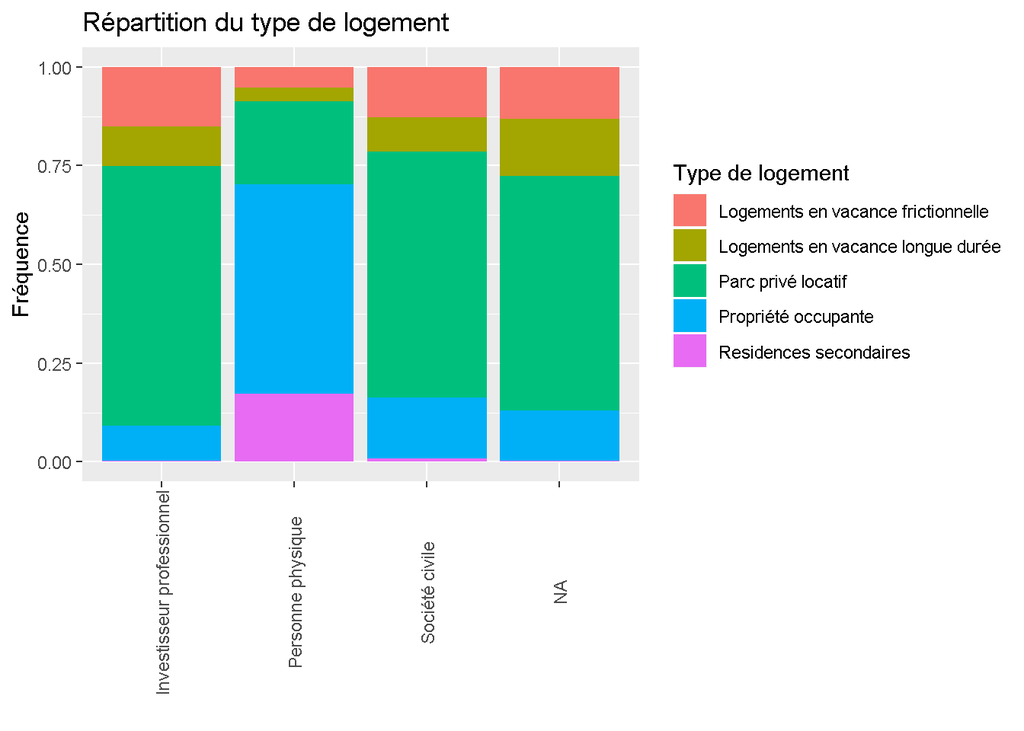

```r
#Variable type_proprietaire
ggplot(data_p, aes(x=as.factor(type_proprietaire)))+
  geom_bar(aes(fill=as.factor(comparaison)),position = "fill")+
  labs(x= '', y="Fréquence")+
  ggtitle("Répartition du type de logement")+
  theme(axis.text.x = element_text(angle = 90, vjust=0.5))+
  scale_fill_discrete(name="Type de logement")
```

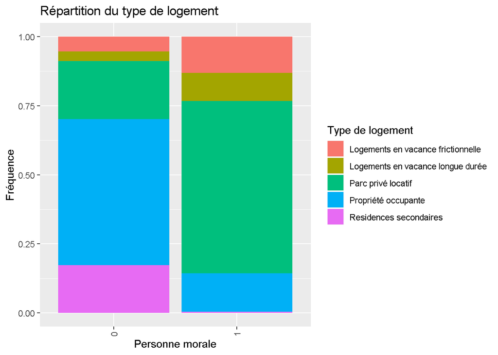

```r
#Variable pers_morale
ggplot(data_p, aes(x=as.factor(pers_morale)))+
  geom_bar(aes(fill=as.factor(comparaison)),position = "fill")+
  labs(x= 'Personne morale', y="Fréquence")+
  ggtitle("Répartition du type de logement")+
  theme(axis.text.x = element_text(angle = 90, vjust=0.5))+
  scale_fill_discrete(name="Type de logement")
```

Le premier graphique, comprenant les types de propriétaires tels que les investisseurs professionnels, les personnes physiques et les sociétés civiles, regroupe une partie de NA non négligeable. Cependant, on peut noter le fait que les proportions d’investisseurs et de sociétés sont plus importants lorsque les logements sont vacants.

C’est également ce que retranscrit le deuxième histogramme, où l’on voit clairement que la proportion de personnes morales est plus importante lorsque les logements sont vacants.

### 2.4.2. Année de naissance du propriétaire

On veut déterminer les années de naissance qui semblent aberrants au regard des données considérées sur la vacance des logements. Pour ce faire, on va réaliser une régression linéaire simple, en régressant la vacance longue durée sur la variable ff_annss. On veut détecter les outliers qui influent sur la régression.

```r
lm1 <- lm(ld_vacancy ~ ff_annss, data= data_p)
```

```r
outlierTest(lm1)
```

```
## No Studentized residuals with Bonferroni p < 0.05
## Largest |rstudent|:
##         rstudent unadjusted p-value Bonferroni p
## 1573611 5.435361         5.4689e-08      0.19382
```

Ici la p-value de Bonferroni est très éloignée de la valeur 0.05. Au regard de la régression, on ne peut donc pas considérer qu’il existe des données aberrantes qui influent sur la prédiction de la vacance longue durée.

```r
which.max(rstudent(lm1))
```

```
## 1573611
## 1452203
```

```r
print(data_p$ff_annss[max(rstudent(lm1))])
```

```
## [1] 1942
```

```r
describe(data_p$ff_annss)
```

```
##    vars       n    mean   sd median trimmed   mad  min  max range  skew
## X1    1 3544087 1957.43 16.6   1957 1957.46 17.79 1910 2018   108 -0.01
##    kurtosis   se
## X1    -0.71 0.01
```

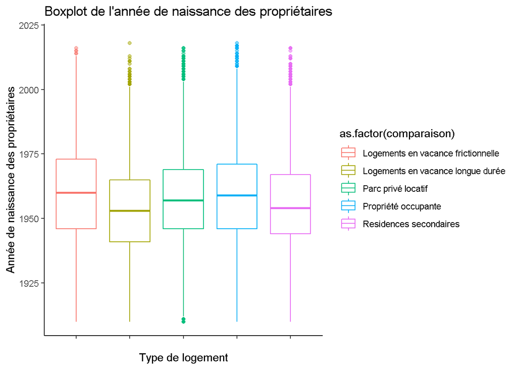

```r
ggplot(data_p,aes(y = ff_annss, x=as.factor(comparaison), colour=as.factor(comparaison)))+
  geom_boxplot(alpha=0.5)+
  theme_classic()+
  labs(x="Type de logement", y="Année de naissance des propriétaires", fill="")+
  ggtitle("Boxplot de l'année de naissance des propriétaires")+
    scale_fill_discrete(name="")+   scale_x_discrete(labels=c("","","", "","","",""))+ coord_cartesian(ylim = c(1910,2020))
```

```r
summary(data_p$ff_annss)
```

```
##    Min. 1st Qu.  Median    Mean 3rd Qu.    Max.    NA's
##    1910    1946    1957    1957    1970    2018  313163
```

```r
summary(data_p$ff_annss[data_p$vacancy==1])
```

```
##    Min. 1st Qu.  Median    Mean 3rd Qu.    Max.    NA's
##    1910    1944    1957    1957    1970    2018   73821
```

```r
summary(data_p$ff_annss[data_p$ld_vacancy==1])
```

```
##    Min. 1st Qu.  Median    Mean 3rd Qu.    Max.    NA's
##    1910    1941    1953    1953    1965    2018   32913
```

On remarque que le groupe qui présente l’âge médian le plus petit est le groupe des logements en situation de vacance frictionnelle. On fait l’hypothèse que cette situation est due au fait que les propriétaires les plus jeunes sont les plus à même d’acheter des biens dont l’année de mutation est récente.

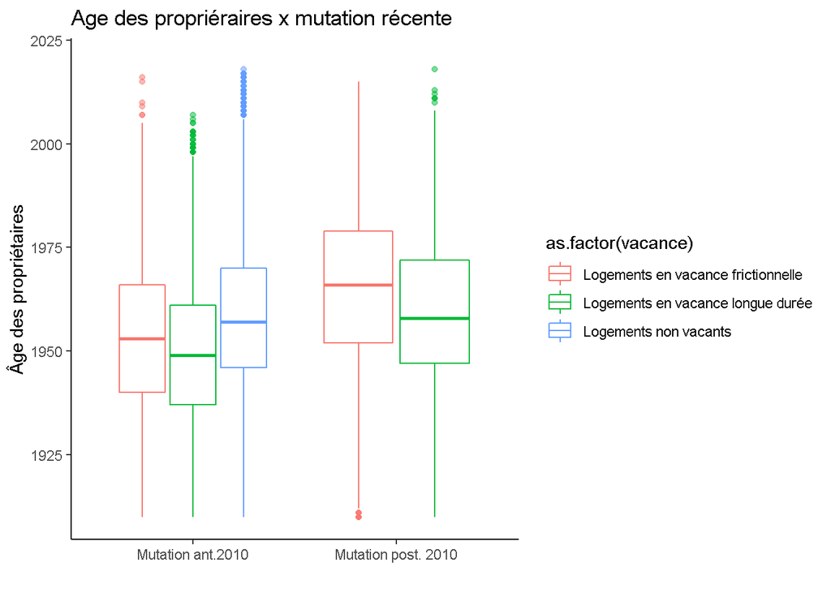

```r
ggplot(data_p,aes(y=ff_annss, x=as.factor(mutation_post_2010), colour=as.factor(vacance)))+
  geom_boxplot(alpha=0.5)+
  theme_classic()+
  labs(x="", y="Âge des propriétaires", fill="")+
  ggtitle("Age des propriéraires x mutation récente")+
    scale_fill_discrete(name="")+   scale_x_discrete(labels=c("Mutation ant.2010"," Mutation post. 2010 "))+ coord_cartesian(ylim = c(1910, 2020))
```

On remarque ici que les propriétaires les plus jeunes sont ceux qui détiennent un bien en situation de vacance frictionnelle dont l’année de mutation est postérieure à 2010.

### 4.3. Nombre de droits des propriétaires

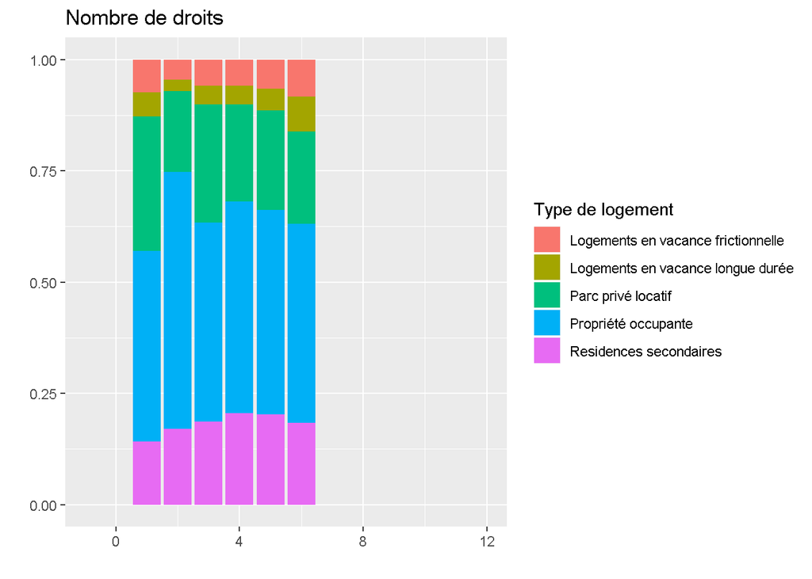

```r
ggplot(data_p,aes(nb_droits, fill=as.factor(comparaison)))+
  geom_bar(position = "fill")+
  labs(title="Nombre de droits", x ="", y = "")+
  scale_fill_discrete(name="Type de logement")+
  xlim(c(-1,12))
```

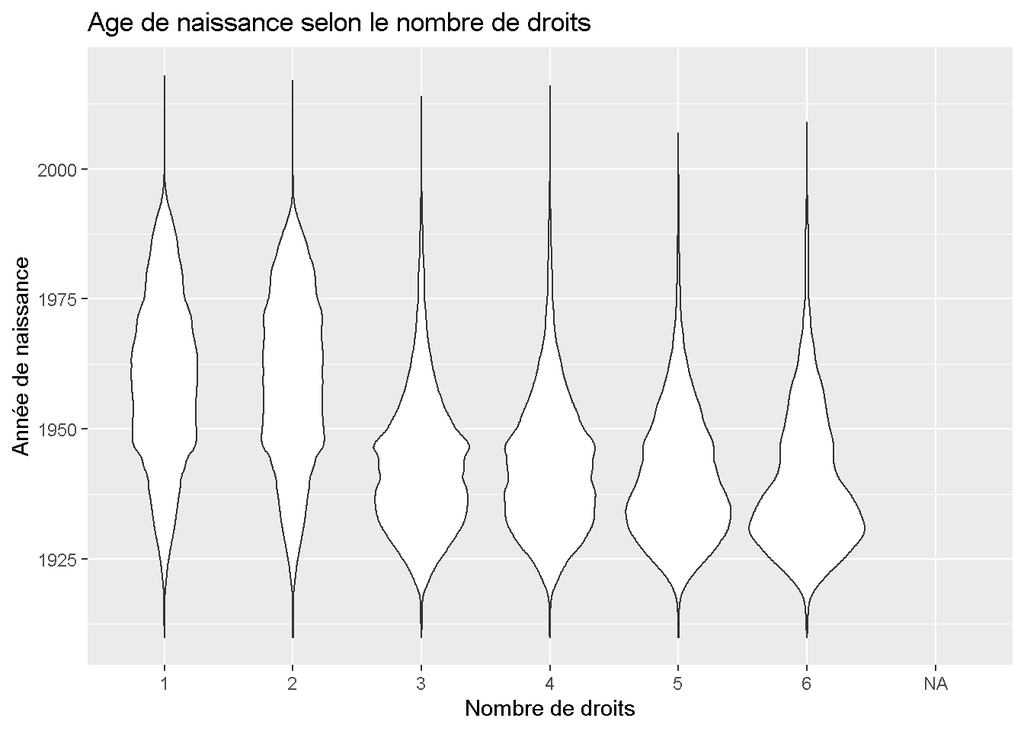

```r
ggplot(data_p, aes(x=as.factor(nb_droits), y= ff_annss)) + scale_x_discrete("Nombre de droits") + geom_violin() +
  labs(title="Age de naissance selon le nombre de droits",x="Nombre de droits", y = "Année de naissance")
```

### 2.4.4. Nombre de logements détenus par les propriétaires

```r
print(describe(data_p$nb_logements))
```

```
##    vars       n  mean     sd median trimmed mad min  max range  skew
## X1    1 3857250 21.22 221.96      1    1.77   0   1 3790  3789 14.26
##    kurtosis   se
## X1    214.5 0.11
```

On cherche à étudier plus précisément la distribution du nombre de logements par propriétaire. Pour ce faire, on réalise un histogramme en fréquence.

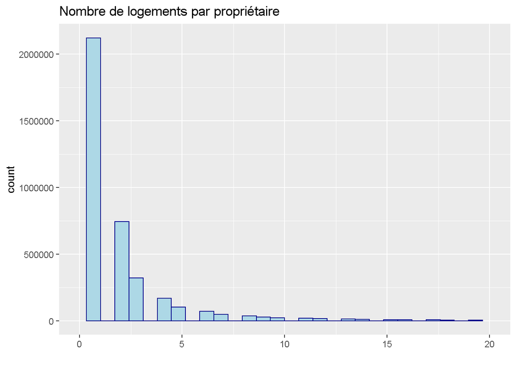

```r
ggplot(data_p, aes(x= nb_logements), bins = 10 )+
  geom_histogram(color="darkblue", fill="lightblue") +
  labs(title="Nombre de logements par propriétaire ")+
  xlab("")+
  xlim(c(0,20))
```

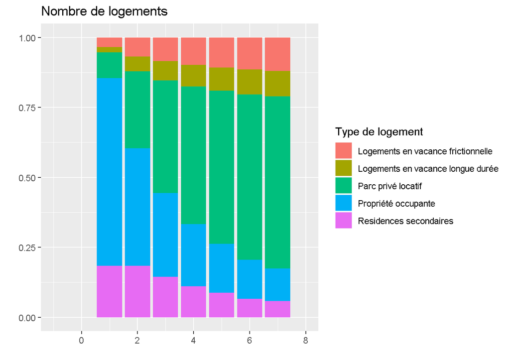

```r
ggplot(data_p,aes(nb_logements, fill=as.factor(comparaison)))+
  geom_bar(position = "fill")+
  labs(title="Nombre de logements", x ="", y = "")+
  scale_fill_discrete(name="Type de logement")+
  xlim(c(-1,8))
```

```r
summary(data_p$nb_logements)
```

```
##    Min. 1st Qu.  Median    Mean 3rd Qu.    Max.
##    1.00    1.00    1.00   21.22    3.00 3790.00
```

### 4.5. Proximité du propriétaire avec le logement

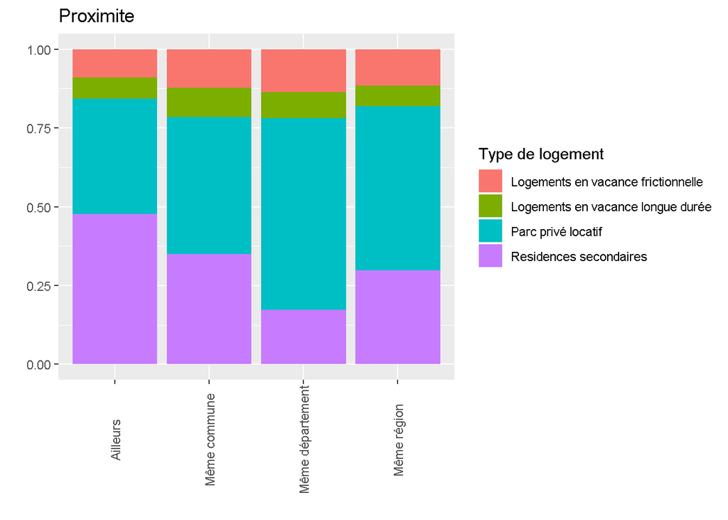

```r
ggplot(data_p %>% filter(comparaison != "Propriété occupante"),aes(as.factor(proximite), fill=as.factor(comparaison)))+
  geom_bar(position = "fill")+
  labs(title="Proximite", x ="", y = "")+
  scale_fill_discrete(name="Type de logement")+
  theme(axis.text.x = element_text(angle = 90, vjust=0.5))
```

On a retiré la propriété occupante de ce graphique, puisque les propriétaires qui occupent leurs logements sont sensés de fait habiter dans la même commune.